# ANÁLISIS DE PLATAFORMAS

# Datos relevantes

Tenemos un conjunto de datos relacionado a peliculas, por lo que se mostrará una pequeña parte del Dataset, en esta primera parte mostraré como está distribuido nuesro conjunto de datos

| ID | Title | Year | Score | Directors | Genres | Country | Language | Runtime |
| --- | --- | --- | --- | --- | --- | --- | --- | --- |
| 1 | The Irishman | 2019 | 8.80 | Martin Scorsese | Biography,Crime,Drama | United States | English,Italian,Latin,Spanish,German | 209 |
| 2 | Dangal | 2016 | 9.05 | Nitesh Tiwari | Action,Biography,Drama,Sport | India,United States,United Kingdom,Australia,Kenya,Namibia | Hindi,English | 161 |
| 3 | David Attenborough: A Life on Our Planet | 2020 | 9.25 | Alastair Fothergill,Jonathan Hughes,Keith Scholey | Documentary,Biography | United Kingdom | English | 83 |
| 4 | Lagaan: Once Upon a Time in India | 2001 | 8.75 | Ashutosh Gowariker | Drama,Musical,Sport | India,United Kingdom | Hindi,English | 224 |
| 5 | Roma | 2018 | 8.55 |  | Action,Drama,History,Romance,War | United Kingdom,United States | English | 52 |
| 6 | To All the Boys I’ve Loved Before | 2018 | 8.25 | Susan Johnson | Comedy,Drama,Romance | United States | English | 99 |
| 7 | The Social Dilemma | 2020 | 8.45 | Jeff Orlowski | Documentary,Drama | United States | English | 94 |
| 8 | Okja | 2017 | 8.25 | Bong Joon Ho | Action,Adventure,Drama,Sci-Fi | South Korea,United States | English,Korean,Spanish | 120 |

## Peliculas

Nos interesa observar quien tiene más contenido, solo contabilizamos las peliculas que se encuentran en una sola plataforma.

| Plataforma | Total |
| --- | --- |
| others | 253 |
| Disney | 900 |
| Hulu | 911 |
| Netflix | 3550 |
| Prime Video | 3901 |

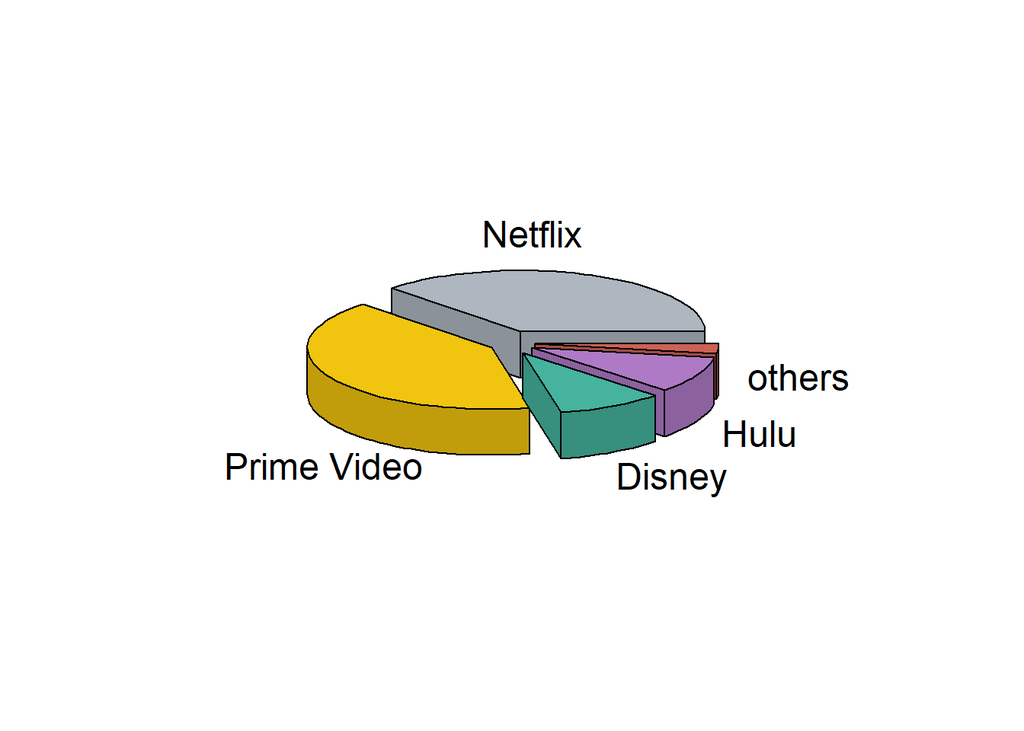

y como lo podemos observar, Prime video es el que más contenido tiene, seguido de Netflix y por último con un gran margen de diferencia se encuentran Disney y Hulu

## Calificaciones

Nos interesa obtener que calificaciones han obtenido las 4 plataformas, tales como: la calificación mínima, la máxima, y el promedio de sus calificaciones otorgadas por IMDb y Rotten Tomatoes.

Como observamos en nuestra sección anterior, Prime Video es el que más contenido tiene, pero el que peor calificaciones obtiene. Por otro lado Disney y Hulu son las que obtienen mejor puntuación, apesar de ser las plataformas con menor cantidad de contenido.

|  | Calif Min | Calif Max | Calif Pomedio |
| --- | --- | --- | --- |
| Netflix | 1.0 | 9.2 | 5.8 |
| Prime Video | 1.2 | 9.1 | 5.4 |
| Disney | 1.0 | 8.8 | 6.1 |
| Hulu | 1.2 | 9.2 | 6.1 |

# Netflix

## Calificación de peliculas por edades

Nos interesa obtener el total de peliculas por rangos de edades, y obtener el rango de edad con mejor calificación para poder promover mejor contenido al usuario

| Age | Total | Puntuacion |
| --- | --- | --- |
| all | 139 | 5.7 |
| 16+ | 149 | 6.1 |
| 7+ | 304 | 6.0 |
| 13+ | 372 | 6.2 |
| 18+ | 842 | 6.2 |

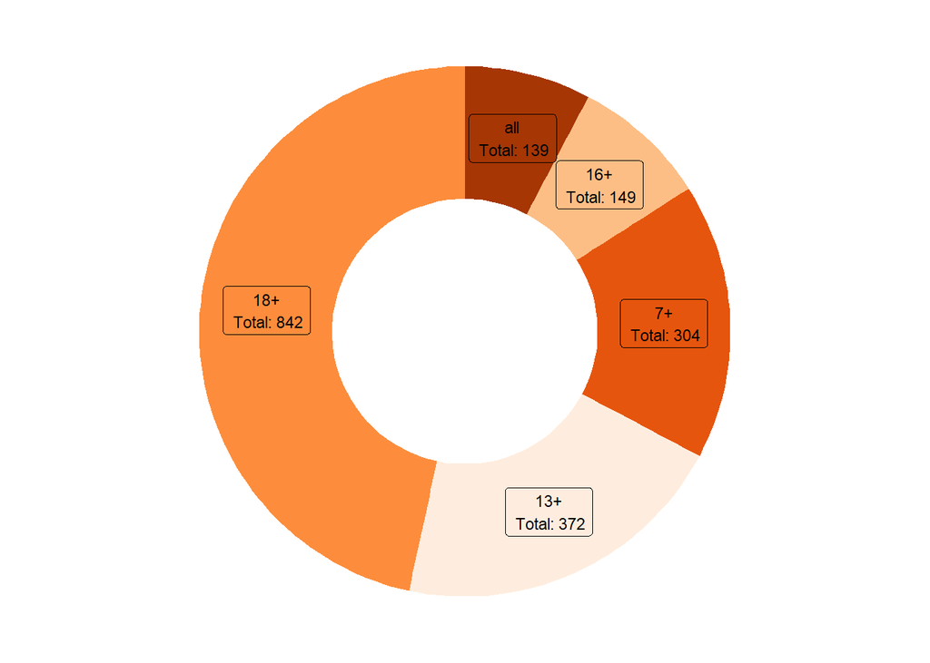

En el contenido de Netflix, predominan las peliculas para usuarios mayores a 18 años, una gran ventaja dado que la mayor cantidad de usuarios son personas mayores a 18

## Calificación de peliculas por años

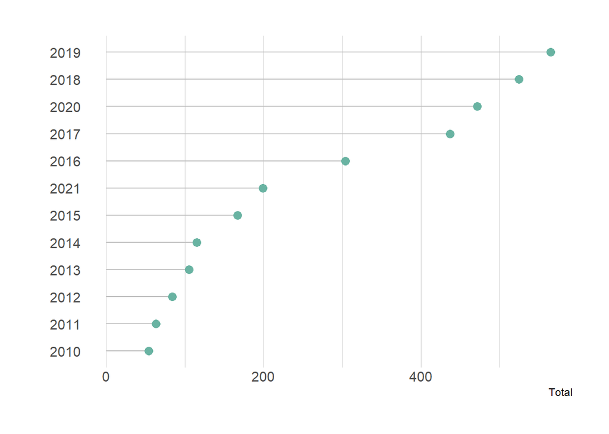

| Year | Total | Puntuacion |
| --- | --- | --- |
| 2010 | 54 | 6.1 |
| 2011 | 63 | 6.1 |
| 2012 | 84 | 5.9 |
| 2013 | 105 | 6.0 |
| 2014 | 115 | 6.0 |
| 2015 | 167 | 5.8 |
| 2021 | 199 | 5.7 |
| 2016 | 304 | 5.7 |
| 2017 | 437 | 5.7 |
| 2020 | 472 | 5.6 |
| 2018 | 525 | 5.7 |
| 2019 | 565 | 5.6 |

Con estos resultados podemos hacer recomendaciones y brindar información para una mejor satisfacción al usuario

## Peliculas mejor calificadas

Mostraremos las 5 peliculas mejor calificadas, para que de esta manera promover esta plataforma y así obtener mayor cantidad de usuarios

| Title | Language | Genres | Directors | Age |
| --- | --- | --- | --- | --- |
| The Irishman | English,Italian,Latin,Spanish,German | Biography,Crime,Drama | Martin Scorsese | 18+ |
| Dangal | Hindi,English | Action,Biography,Drama,Sport | Nitesh Tiwari | 7+ |
| David Attenborough: A Life on Our Planet | English | Documentary,Biography | Alastair Fothergill,Jonathan Hughes,Keith Scholey | 7+ |
| Lagaan: Once Upon a Time in India | Hindi,English | Drama,Musical,Sport | Ashutosh Gowariker | 7+ |
| Black Friday | Hindi,English | Action,Crime,Drama,History | Anurag Kashyap | 18+ |

# Bibliografía

[1] Diseño de gráficas [Graph Gallery](https://www.r-graph-gallery.com/)

[2] Diseño de Tablas [Hao Zhu](https://cran.r-project.org/web/packages/kableExtra/vignettes/awesome_table_in_html.html)